# Stablecoins: USDC, USDT and DAI

Riccardo Paravano

## Introduction

The aim of this analysis is to compare the transfer sizes and volumes of three Ethereum stablecoins: USDC, USDT and DAI.

We retrieve up to 1,000 recent ERC-20 transfer events for each token and remove transfers with a value of zero.

```r
library(dplyr)
library(ggplot2)
library(httr2)
library(knitr)
```

## Data preparation

```r
api_key <- Sys.getenv("ETHERSCAN_API_KEY")
```

We use the Etherscan `tokentx` endpoint to retrieve the transfers of each token.

```r
get_transfers <- function(token, contract) {
  response <- request("https://api.etherscan.io/v2/api") |>
    req_url_query(
      chainid = 1,
      module = "account",
      action = "tokentx",
      contractaddress = contract,
      page = 1,
      offset = 1000,
      sort = "desc",
      apikey = api_key
    ) |>
    req_perform() |>
    resp_body_json(simplifyVector = TRUE)

  response$result |>
    as.data.frame() |>
    transmute(
      Token = token,
      Time = as.POSIXct(as.numeric(timeStamp), origin = "1970-01-01", tz = "UTC"),
      Hash = hash,
      From = from,
      To = to,
      Amount = as.numeric(value) / 10^as.numeric(tokenDecimal)
    )
}

usdc <- get_transfers("USDC", "0xa0b86991c6218b36c1d19d4a2e9eb0ce3606eb48")
usdt <- get_transfers("USDT", "0xdac17f958d2ee523a2206206994597c13d831ec7")
dai <- get_transfers("DAI", "0x6b175474e89094c44da98b954eedeac495271d0f")

stablecoins <- bind_rows(usdc, usdt, dai) |>
  filter(Amount > 0)

glimpse(stablecoins)
```

```
## Rows: 2,720
## Columns: 6
## $ Token  <chr> "USDC", "USDC", "USDC", "USDC", "USDC", "USDC", "USDC", "USDC",…
## $ Time   <dttm> 2026-11-01 20:05:59, 2026-11-01 20:05:59, 2026-11-01 20:05:59,…
## $ Hash   <chr> "0xb4ebd3078b11e2140f8319f46375f8bc7b5cdc426e870fc2a7cdbc24e2ff…
## $ From   <chr> "0x050ebe3dbb4b3a3526735b04cc3d96c80609ee7e", "0x085ce041d9ac14…
## $ To     <chr> "0x3b81fd1d0044750ed51e9dc2610ff48d6ca07a93", "0x6872b6630a3afc…
## $ Amount <dbl> 29.704865, 203.616333, 203.000000, 1045.716774, 155.860615, 379…
```

After removing zero-value transfers, the dataset contains 2,720 transfers: DAI 948, USDC 911, USDT 861.

# Challenge 1: How do transfer sizes differ?

CHALLENGE: “How do the transfer sizes of USDC, USDT and DAI differ?”

We summarize the transfer amounts of each stablecoin.

```r
transfer_sizes <- stablecoins |>
  group_by(Token) |>
  summarise(
    Transfers = n(),
    Minimum = min(Amount),
    Median = median(Amount),
    Mean = mean(Amount),
    Maximum = max(Amount)
  )

transfer_sizes |>
  mutate(across(Minimum:Maximum, ~ format(round(.x, 2), big.mark = ","))) |>
  kable()
```

| Token | Transfers | Minimum | Median | Mean | Maximum |
| --- | --- | --- | --- | --- | --- |
| DAI | 948 | 0 | 532.37 | 126,804.36 | 15,000,000 |
| USDC | 911 | 0 | 133.06 | 29,208.77 | 8,779,001 |
| USDT | 861 | 0 | 99.73 | 50,502.56 | 40,000,000 |

DAI has the highest median at 532.37. DAI has the highest mean at 126,804.36. The mean exceeds the median for 3 of the 3 tokens, showing the effect of large transfers.

We compare the distributions on a logarithmic scale because the transfer amounts vary greatly.

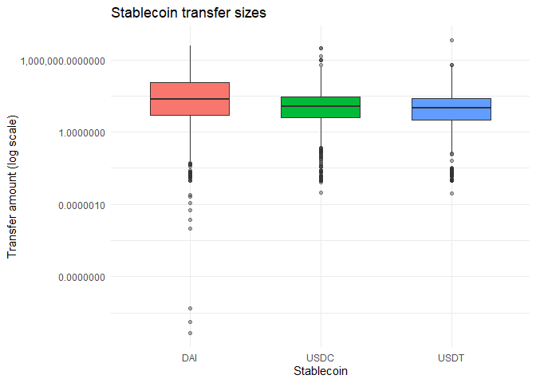

```r
ggplot(data = stablecoins, mapping = aes(x = Token, y = Amount, fill = Token)) +
  geom_boxplot(width = 0.6, outlier.alpha = 0.4, show.legend = FALSE) +
  scale_y_log10(labels = scales::label_number(big.mark = ",")) +
  labs(
    title = "Stablecoin transfer sizes",
    x = "Stablecoin",
    y = "Transfer amount (log scale)"
  ) +
  theme_minimal()
```

The highest observed transfer belongs to USDT and is worth 40,000,000.00. The smallest median is 99.73 for USDT.

We can also inspect the full distribution of transfer amounts.

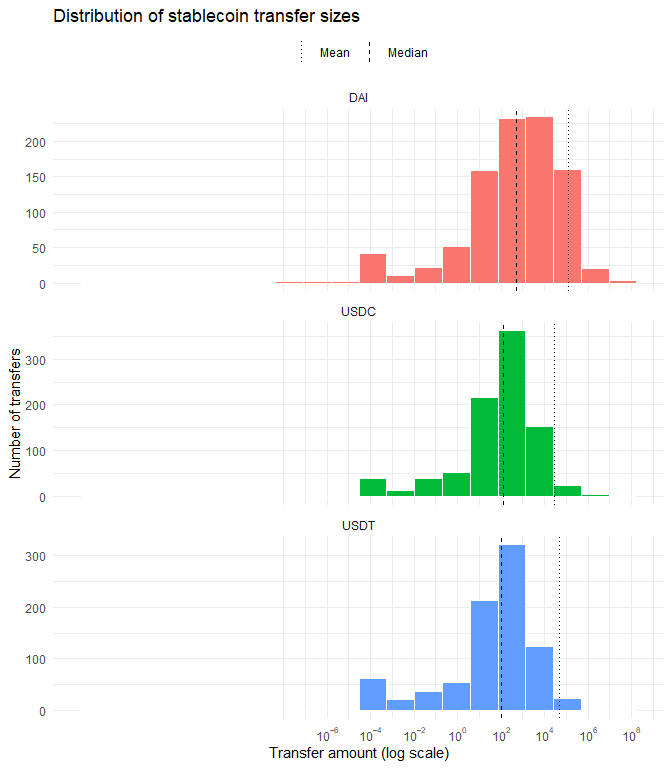

```r
ggplot(data = stablecoins, mapping = aes(x = Amount, fill = Token)) +
  geom_histogram(bins = 20, colour = "white", show.legend = FALSE) +
  geom_vline(
    data = transfer_sizes,
    mapping = aes(xintercept = Median, linetype = "Median"),
    colour = "black"
  ) +
  geom_vline(
    data = transfer_sizes,
    mapping = aes(xintercept = Mean, linetype = "Mean"),
    colour = "black"
  ) +
  scale_x_log10(
    breaks = 10^seq(-6, 8, 2),
    labels = scales::label_log()
  ) +
  scale_linetype_manual(
    values = c("Median" = "dashed", "Mean" = "dotted"),
    name = NULL
  ) +
  facet_wrap(~ Token, ncol = 1, scales = "free_y") +
  labs(
    title = "Distribution of stablecoin transfer sizes",
    x = "Transfer amount (log scale)",
    y = "Number of transfers"
  ) +
  theme_minimal() +
  theme(legend.position = "top")
```

For 3 of the 3 tokens, the mean is above the median. This indicates that a limited number of large transfers raise the average.

# Challenge 2: How much transfer volume does each stablecoin generate?

CHALLENGE: “How much transfer volume does each stablecoin generate?”

We calculate the total and average volume of the positive transfers retrieved for each stablecoin.

```r
transfer_volumes <- stablecoins |>
  group_by(Token) |>
  summarise(
    Transfers = n(),
    TotalVolume = sum(Amount),
    AverageVolume = mean(Amount)
  ) |>
  arrange(desc(TotalVolume))

transfer_volumes |>
  mutate(across(c(TotalVolume, AverageVolume), ~ format(round(.x, 2), big.mark = ","))) |>
  kable()
```

| Token | Transfers | TotalVolume | AverageVolume |
| --- | --- | --- | --- |
| DAI | 948 | 120,210,534 | 126,804.36 |
| USDT | 861 | 43,482,700 | 50,502.56 |
| USDC | 911 | 26,609,193 | 29,208.77 |

DAI has the highest total volume at 120,210,534.39, followed by USDT at 43,482,700.32 and USDC at 26,609,192.83.

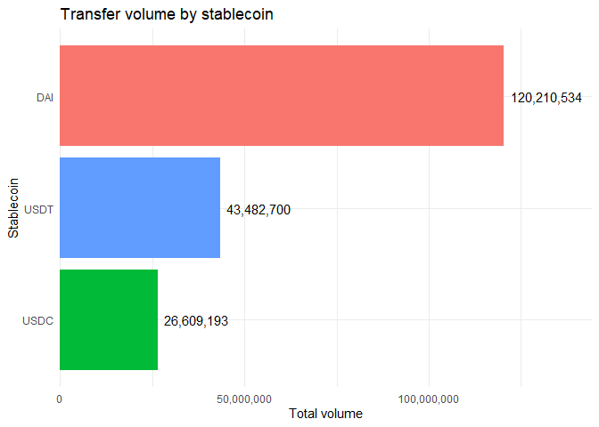

```r
ggplot(
  data = transfer_volumes,
  mapping = aes(x = reorder(Token, TotalVolume), y = TotalVolume, fill = Token)
) +
  geom_col(show.legend = FALSE) +
  geom_text(
    mapping = aes(label = scales::comma(TotalVolume, accuracy = 1)),
    hjust = -0.1
  ) +
  coord_flip() +
  scale_y_continuous(
    labels = scales::comma,
    expand = expansion(mult = c(0, 0.2))
  ) +
  labs(
    title = "Transfer volume by stablecoin",
    x = "Stablecoin",
    y = "Total volume"
  ) +
  theme_minimal()
```

The volume of DAI is 2.8 times that of USDT. The average transfer values range from 29,208.77 to 126,804.36.